# What Factors Affect Home Ownership?

## Comparative Analysis of the Determinants of Home Ownership Between the Great Recession

### Authors: Isabella Aguado, Jihan Lee, Hilary Klein, Audrey Margolies

I. Introduction and Motivation

> a. Literature Review

> b. Figures

II. Data

> a. Preprocessing

> b. Explanation

> c. Variable

III. Exploratory Data Analysis

> a. Descriptive Statistics

> b. Data Visualization

IV. Methodology/Empirical Model

> a. Economic Hypothesis

V. Regression Analysis

> a. Multicollinearity

> b. Ordinary Least Squared (OLS) Linear Regression

> c. Heteroskedasticity

> d. Normality of Residuals

VI. Conclusion & Discussion

VII. References

# I. Introduction and Motivation

The topic of home ownership holds immense significance in the context of the United States, reflecting not only economic stability but also broader societal patterns. In recent years, the dynamics of home ownership have evolved as demographic, economic, and social factors have changed. This project investigates the determinants of home ownership within the United States.

The severity of the Great Recession (2007-09) forced many people into foreclosure and prevented others from buying homes because of tightened lending standards or reduced income. As people's lives changed, the factors that have affected home ownership became less or more important (St. Louis Federal Reserve Bank). Did being married, and therefore having a dual income, save certain people from losing their homes? Were people of color more severely affected than whites? We seek to uncover the change in these determinants in this analysis.

According to Illinois Wesleyan University, the impact of home ownership determinants has fluctuated with the economy: “Marital status remains important to the home ownership decision, though its effect has weakened. The impact of the level of education is now just as important as the presence of children in a household” (IWU, 1999). The context of this study spans various societal and economic dynamics in the U.S. housing market. Historically, home ownership has been a critical measure of economic stability and societal status. The landscape of home ownership has evolved over time, influenced by shifts in economic conditions, demographic trends, and policy changes.

Understanding the dynamics of home ownership is vital for policymakers, economists, and the general public. It sheds light on economic disparities, social mobility, and the overall health of the real estate market. This research could inform policies aimed at addressing inequalities in housing and aiding those struggling to attain homeownership.

## a. Literature Review

Various studies highlight the significance of factors like marital status, race, gender, and income in home ownership. For instance, married couples tend to have higher home ownership rates compared to unmarried individuals, illustrating the influence of combined income and stability. “Marital status remains important to the home ownership decision, though its effect has weakened. The impact of the level of education is now just as important as the presence of children in a household” (IWU, 1999).

Higher family incomes not only provide the means to cover initial home ownership costs but also improve credit conditions, making home ownership more accessible and financially attractive (Hood). Racial disparities in home ownership rates are evident, with white households owning homes at higher rates than black households, partly due to historical discrimination and differences in income. The role of gender is also significant, as male household heads often have more stable incomes, influencing their likelihood of home ownership. Furthermore, income level is a crucial determinant; higher income increases the likelihood of owning a home due to the ability to cover upfront costs and secure favorable mortgage terms (Carliner). According to the IWU research, important factors like marital status, education level, and the presence of children significantly influence home ownership. These elements' impact on home ownership decisions has evolved alongside societal and economic changes. According to Brookings analyst Jenny Schuetz, discrimination in housing has contributed to substantial wealth gaps between Black and white households. Black and Latino or Hispanic families are less likely to own their homes than white families with similar incomes. Older households, typically having more wealth and income certainty, are more likely to invest in home ownership. This trend correlates with their lower mobility and higher ability to diversify investments (Hood).

## b. Figures

[figure not shown]

By exploring a dataset from IPUMS containing cross-sectional data in the years 2007 and 2009, we aim to uncover insights into the complex interplay of variables such as sex, race/ethnicity, education level, marital status, income, family size, and region. This research strives to contribute to understanding home ownership disparities and the changing landscape of housing in the United States.

# II. Data

For this project, we use Current Population Survey (CPS) data from IPUMS. The population group for this study is people living in the United States-specifically the head of household. The specific variables that we will use for determining the largest determinants of home ownership in 2007 vs. 2009 based on our literature review are race, sex, marital status, family size, education level, hours worked per week, income, and region.

```python
# Import packages
import pandas as pd
import numpy as np
import matplotlib.pyplot as plt
import seaborn as sns
import statsmodels.formula.api as smf
from stargazer.stargazer import Stargazer
from IPython.core.display import HTML

# Import data
cps = pd.read_csv("data/cps.csv")
```

### Initial Variables of the Dataset

Following table shows the variables included in our dataset and their labels before we proceed with preprocessing.

| **Variable** | **Labels** |
| --- | --- |
| YEAR | Survey years |
| OWNERSHP | Ownership of dwelling |
| REGION | Region and division |
| AGE | Age |
| SEX | Sex |
| RACE | Race |
| MARST | Marital status |
| FAMSIZE | Number of own family members in household |
| EDUC | Educational attainment |
| UHRSWORKLY | Usual hours worked per week (last yr) |
| INCTOT | Total personal income |
| LOGINCTOT | Log total personal income |
| RELATE | Relationship to household head |

## a. Preprocessing

```python
cps['REGION'] = cps['REGION'].replace({11:0, 12:0, 21:1, 22:1, 31:2, 32:2, 33:2, 41:3, 42:3}) # 0: Northeast Region, 1: Midwest Region, 2: South Region, 3: West Region
cps['OWNERSHP'] = cps['OWNERSHP'].replace({10:1, 21:0, 22:0}) # 0: Not Owned, 1: Owned
cps['SEX'] = cps['SEX'].replace({2:1, 1:0}) # 0: Male, 1: Female
cps['RACE'] = cps['RACE'].replace({100:0, 200:1, 300:1, 651:1, 652:1}) # 0: White, 1: Non-White
cps['RACE'] = cps['RACE'].astype(str)
cps.loc[cps['RACE'].str.match('8\d{2}'), 'RACE'] = 1
cps['RACE'] = cps['RACE'].astype(int)
cps['MARST'] = cps['MARST'].replace({1:0, 2:0, 3:1, 4:1, 5:1, 6:1}) # 0: Married, 1: Single
cps.drop(cps[cps['UHRSWORKLY'] == 999].index, inplace=True) # Filter out NIU values
cps = cps[cps['RELATE'] == 101] # Filter out only Head/householder
cps = cps[cps['INCTOT'] > 0] # Filter out negative income values
cps['LOGINCTOT'] = np.log(cps['INCTOT']) # Add log-transformed income variable
cps['EDUC'] = cps['EDUC'].replace({2:0, 10:0, 20:0, 30:0, 40:0, 50:0, 60:0, 71:0, 73:0, 81:1, 91:1, 92:1, 111:1, 123:1, 124:1, 125:1}) # 0: Not College Educated, 1: College Educated
# Separate 2007 and 2009 data
cps2007 = cps[cps['YEAR'] == 2007]
cps2009 = cps[cps['YEAR'] == 2009]
# Drop YEAR and RELATE variables
cps2007 = cps2007.drop(['YEAR', 'RELATE'], axis=1)
cps2009 = cps2009.drop(['YEAR', 'RELATE'], axis=1)
```

## b. Explanation

### Recode of Values in Certain Variables

We recoded categorical variables for clarity and consistency of our analysis. This is a common practice in data preparation, especially when dealing with survey data like CPS.

- REGION: grouped values in four of each regional division.
- OWNERSHP: converted into a binary variable (0 = Not Owned, 1 = Owned).
- SEX: recoded into a binary variable for the sake of consistency in the analysis.
- RACE: simplified the categories into White and Non-White to make it into a binary variable.
- MARST: recoded into a binary variable (0 = Married, 1 = Single).
- EDUC: recoded into a binary variable (0 = Not College Educated, 1 = College Educated).

### Filter Data

- Removed entries with UHRSWORKLY as 999 (Not in Universe) and filtered for head/householder (RELATE == 101).
- Filtered out negative income values before making log transformation.

### Log Transformation

- To address the skewed distribution of income data and to linearize relationships for subsequent regression analysis, we apply a natural logarithm transformation to the total personal income variable.
- e.g., if after the transformation, an income data point is 10 on the log scale, it corresponds to an actual income of $e^{10}$ or approximately $22,026.47.

### Create Separate DataFrames for 2007 and 2009 Data

- Separated DataFrames into two cross-sectional data to give clarity for our year-specific insights and comparisons.

### Drop Unnecessary Columns

- Dropped YEAR and RELATE variable, which will not be necessary for future analysis.

## c. Variable

```python
%%capture
%pip install prettytable
```

```python
from prettytable import PrettyTable

variables = ['OWNERSHP', 'REGION', 'AGE', 'SEX', 'RACE', 'MARST', 'FAMSIZE', 'EDUC', 'UHRSWORKLY', 'INCTOT', 'LOGINCTOT']

explanation = [
    'Ownership of dwelling \n 0 = Not Owned \n 1 = Owned',
    'Region and division \n 0 = Northeast Region \n 1 = Midwest Region \n 2 = South Region \n 3 = West Region',
    'Age \n Range: 0-85 \n 80-84 coded as 80, 85+ coded as 85',
    'Sex \n 0 = Male \n 1 = Female',
    'Race \n 0 = White \n 1 = Non-White',
    'Marital status \n 0 = Married \n 1 = Single',
    'Number of own family members in household \n 2-digit numeric variable',
    'Educational attainment;\n 0 = Not College Eduated \n 1 = College Educated',
    'Usual hours worked per week (last yr) \n Range: 0-99 \n 99 = 99 hours or more',
    'Total personal income > 0',
    'Logarithmized total personal income'
]

table = PrettyTable()
table.add_column("Variable", variables)
table.add_column("Explanation", explanation)

table
```

| Variable | Explanation |
| --- | --- |
| OWNERSHP | Ownership of dwelling 0 = Not Owned 1 = Owned |
| REGION | Region and division 0 = Northeast Region 1 = Midwest Region 2 = South Region 3 = West Region |
| AGE | Age Range: 0-85 80-84 coded as 80, 85+ coded as 85 |
| SEX | Sex 0 = Male 1 = Female |
| RACE | Race 0 = White 1 = Non-White |
| MARST | Marital status 0 = Married 1 = Single |
| FAMSIZE | Number of own family members in household 2-digit numeric variable |
| EDUC | Educational attainment; 0 = Not College Eduated 1 = College Educated |
| UHRSWORKLY | Usual hours worked per week (last yr) Range: 0-99 99 = 99 hours or more |
| INCTOT | Total personal income > 0 |
| LOGINCTOT | Logarithmized total personal income |

# III. Exploratory Data Analysis

## a. Descriptive Statistics

### Descriptive Statistics of 2007 Data

```python
cps2007[['AGE', 'FAMSIZE', 'UHRSWORKLY', 'INCTOT', 'LOGINCTOT']].describe().round(2)
```

|  | AGE | FAMSIZE | UHRSWORKLY | INCTOT | LOGINCTOT |
| --- | --- | --- | --- | --- | --- |
| count | 54279.00 | 54279.00 | 54279.00 | 54279.00 | 54279.00 |
| mean | 43.35 | 2.84 | 40.63 | 50150.96 | 10.44 |
| std | 12.53 | 1.49 | 11.42 | 57267.46 | 0.94 |
| min | 15.00 | 1.00 | 1.00 | 1.00 | 0.00 |
| 25% | 34.00 | 2.00 | 40.00 | 21800.00 | 9.99 |
| 50% | 43.00 | 3.00 | 40.00 | 36400.00 | 10.50 |
| 75% | 52.00 | 4.00 | 45.00 | 60000.00 | 11.00 |
| max | 85.00 | 15.00 | 99.00 | 884929.00 | 13.69 |

### Descriptive Statistics of 2009 Data

```python
cps2009[['AGE', 'FAMSIZE', 'UHRSWORKLY', 'INCTOT', 'LOGINCTOT']].describe().round(2)
```

|  | AGE | FAMSIZE | UHRSWORKLY | INCTOT | LOGINCTOT |
| --- | --- | --- | --- | --- | --- |
| count | 54484.00 | 54484.00 | 54484.00 | 54484.00 | 54484.00 |
| mean | 43.83 | 2.83 | 40.10 | 51442.20 | 10.47 |
| std | 12.73 | 1.50 | 11.65 | 54893.39 | 0.94 |
| min | 15.00 | 1.00 | 1.00 | 1.00 | 0.00 |
| 25% | 34.00 | 2.00 | 40.00 | 22147.50 | 10.01 |
| 50% | 44.00 | 3.00 | 40.00 | 38355.50 | 10.55 |
| 75% | 53.00 | 4.00 | 43.00 | 62000.00 | 11.03 |
| max | 85.00 | 15.00 | 99.00 | 691670.00 | 13.45 |

## b. Data Visualization

[interactive chart not shown]

- Histograms
- Pie Charts
- Corrleation Heatmaps

```python
# Functions for plots
def histogram(variable, title, xlabel, ax):
    ax.hist(variable, edgecolor='black')
    ax.set_title(title)
    ax.set_xlabel(xlabel)
    ax.set_ylabel('Frequency')

def piechart(variable, title, label, ax):
    labels = variable.map(label).value_counts().index
    sizes = variable.map(label).value_counts().values
    ax.pie(sizes, autopct=lambda pct: '{:.2f}%'.format(pct) if pct > 5 else '', startangle=140)
    ax.legend(labels, title="Categories", loc="best")
    ax.set_title(title)
    ax.axis('equal')

def heatmap(corr, title):
    sns.heatmap(corr, annot=True, cmap='coolwarm')
    plt.title(title)
    plt.show()
```

### Histograms

**Histograms of 2007 Data**

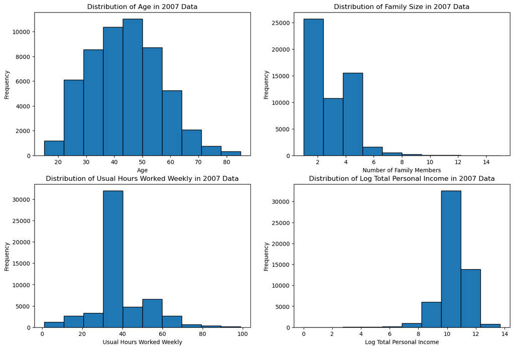

```python
fig, ax = plt.subplots(nrows=2, ncols=2, figsize=(15, 10))

histogram(cps2007['AGE'], 'Distribution of Age in 2007 Data', 'Age', ax[0, 0])
histogram(cps2007['FAMSIZE'], 'Distribution of Family Size in 2007 Data', 'Number of Family Members', ax[0, 1])
histogram(cps2007['UHRSWORKLY'], 'Distribution of Usual Hours Worked Weekly in 2007 Data', 'Usual Hours Worked Weekly', ax[1, 0])
histogram(cps2007['LOGINCTOT'], 'Distribution of Log Total Personal Income in 2007 Data', 'Log Total Personal Income', ax[1, 1])

plt.show()
```

#### **Interpretation**

- Age: The age distribution displays a relatively even spread with a minor skew towards the right, indicating a prevalence of middle-aged heads of households. This group is often linked with higher rates of homeownership, suggesting that life stability and progression through life stages enhance the ability to own homes.
- Family Size: The dataset primarily features families with two members, indicating a dominance of smaller family units. The presence of children in a household is an important factor, often accelerating the pursuit of homeownership for the benefits of security and additional space.
- Usual Hours Worked Weekly: The data shows a significant concentration of individuals working around 40 hours per week, which aligns with typical full-time employment. This pattern suggests a consistent source of income for many, crucial for the financial stability necessary in acquiring a home.
- Log Total Personal Income: The logarithmic transformation of total personal income reveals a clustering in the middle to upper ranges. By normalizing income data, this approach facilitates more effective use of linear regression methods to explore how income influences the probability of homeownership.

**Histograms of 2009 Data**

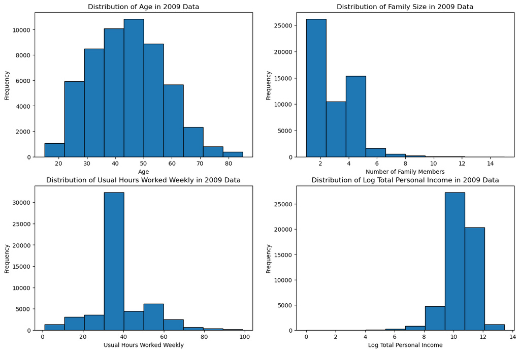

```python
fig, ax = plt.subplots(nrows=2, ncols=2, figsize=(15, 10))

histogram(cps2009['AGE'], 'Distribution of Age in 2009 Data', 'Age', ax[0, 0])
histogram(cps2009['FAMSIZE'], 'Distribution of Family Size in 2009 Data', 'Number of Family Members', ax[0, 1])
histogram(cps2009['UHRSWORKLY'], 'Distribution of Usual Hours Worked Weekly in 2009 Data', 'Usual Hours Worked Weekly', ax[1, 0])
histogram(cps2009['LOGINCTOT'], 'Distribution of Log Total Personal Income in 2009 Data', 'Log Total Personal Income', ax[1, 1])

plt.show()
```

#### **Interpretation**

- Age: The age distribution mirrors that of 2007, highlighting a consistent demographic landscape across the two years. The significant presence of the working-age population is key, as this group is often in a life stage where achieving homeownership is a major objective.
- Family Size: There is a slight trend towards smaller families compared to 2007, possibly reflecting shifts in household structures during economic downturns. However, this change is minor and not a drastic departure from the 2007 figures.
- Usual Hours Worked Weekly: The data continues to show a dominant peak at the 40-hour workweek mark, in line with the 2007 findings. This consistency indicates a stable employment pattern over these years.
- Log Total Personal Income: The log transformation of personal income reveals a pronounced focus in the middle to upper income ranges. This trend could be a result of the economic recession influencing income distributions, potentially limiting homeownership opportunities primarily to those in higher income brackets.

### Pie Charts

**Pie Charts of Home Ownership**

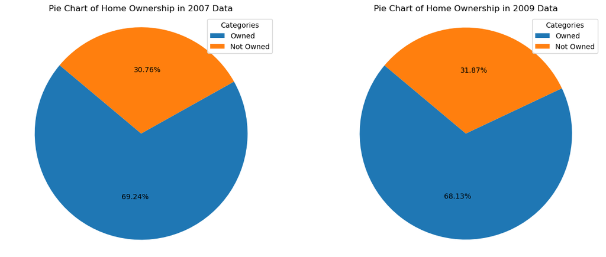

```python
fig, ax = plt.subplots(nrows=1, ncols=2, figsize=(15, 6))

piechart(cps2007['OWNERSHP'], 'Pie Chart of Home Ownership in 2007 Data', {0:'Not Owned', 1:'Owned'}, ax[0])
piechart(cps2009['OWNERSHP'], 'Pie Chart of Home Ownership in 2009 Data', {0:'Not Owned', 1:'Owned'}, ax[1])
```

#### Home Ownership in 2007

The majority of household heads owning their homes suggests that prior to the Great Recession, a considerable segment of the population was engaged in the housing market. This indicates a phase of relative economic stability, where homeownership was a prevalent and achievable goal for many.

#### Home Ownership in 2009

There has been a minor decline in homeownership, dropping to 68.13%. This small decrease may signify the early effects of the Great Recession on people's capacity to maintain their homes or to access the housing market for the first time.

**Pie Charts of 2007 Data**

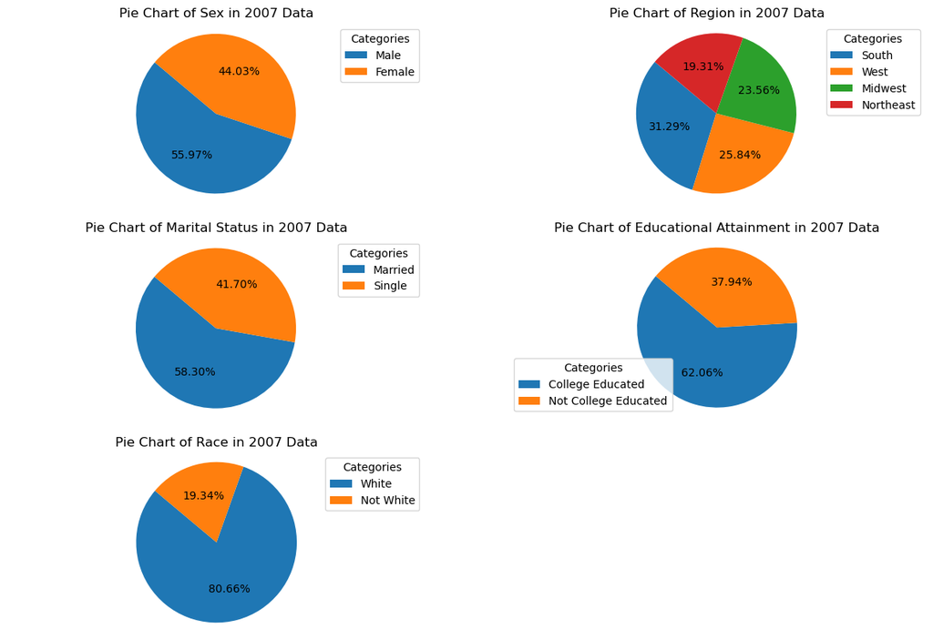

```python
fig, ax = plt.subplots(nrows=3, ncols=2, figsize=(15, 10))

piechart(cps2007['SEX'], 'Pie Chart of Sex in 2007 Data', {0:'Male', 1:'Female'}, ax[0, 0])
piechart(cps2007['REGION'], 'Pie Chart of Region in 2007 Data', {0:'Northeast', 1:'Midwest', 2:'South', 3:'West'}, ax[0, 1])
piechart(cps2007['MARST'], 'Pie Chart of Marital Status in 2007 Data', {0:'Married', 1:'Single'}, ax[1, 0])
piechart(cps2007['EDUC'], 'Pie Chart of Educational Attainment in 2007 Data', {0:'Not College Educated', 1:'College Educated'}, ax[1, 1])
piechart(cps2007['RACE'], 'Pie Chart of Race in 2007 Data', {0:'White', 1:'Not White'}, ax[2, 0])

fig.delaxes(ax[-1, -1])
plt.show()
```

**Pie Charts of 2009 Data**

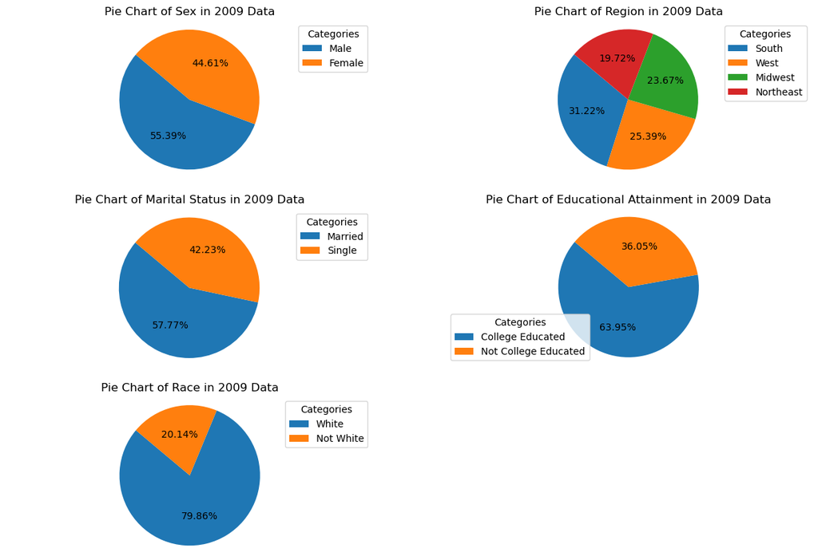

```python
fig, ax = plt.subplots(nrows=3, ncols=2, figsize=(15, 10))

piechart(cps2009['SEX'], 'Pie Chart of Sex in 2009 Data', {0: 'Male', 1: 'Female'}, ax[0, 0])
piechart(cps2009['REGION'], 'Pie Chart of Region in 2009 Data', {0:'Northeast', 1:'Midwest', 2:'South', 3:'West'}, ax[0, 1])
piechart(cps2009['MARST'], 'Pie Chart of Marital Status in 2009 Data', {0:'Married', 1:'Single'}, ax[1, 0])
piechart(cps2009['EDUC'], 'Pie Chart of Educational Attainment in 2009 Data', {0:'Not College Educated', 1:'College Educated'}, ax[1, 1])
piechart(cps2009['RACE'], 'Pie Chart of Race in 2009 Data', {0:'White', 1:'Not White'}, ax[2, 0])

fig.delaxes(ax[-1, -1])
plt.show()
```